# R Notebook

### EDA (Exloratory data analysis) on the nycflights13 data package

Step 1: installing packages and data

```r
if (! "pacman" %in% installed.packages()[, 1])
  install.packages("pacman")

p_load <- pacman::p_load

p_load("tidyverse")
p_load("nycflights13")
p_load("glue")
p_load("maps")
p_load("treemapify")
```

#### Airlines

```r
airlines%>%
    dplyr::select(name)%>%
    unique()
```

| name |
| --- |
| Endeavor Air Inc. |
| American Airlines Inc. |
| Alaska Airlines Inc. |
| JetBlue Airways |
| Delta Air Lines Inc. |
| ExpressJet Airlines Inc. |
| Frontier Airlines Inc. |
| AirTran Airways Corporation |
| Hawaiian Airlines Inc. |
| Envoy Air |

[output cut: 6 more lines]

How many distinct airlines are there?

```r
airlines%>%
  dplyr::select(name)%>%
  unique()%>%
  nrow()
```

```
## [1] 16
```

#### Airports

How many airports are there in the dataset

```r
airports%>%
  dplyr::select(faa)%>%
  unique()%>%
  nrow()
```

```
## [1] 1458
```

There are 1458 airports.

Map with the locations of all US based airports

```r
airport_map <- airports%>%
  dplyr::select(name, lon, lat)%>%
  dplyr::filter(lon < 0)
US <- map_data("usa")
```

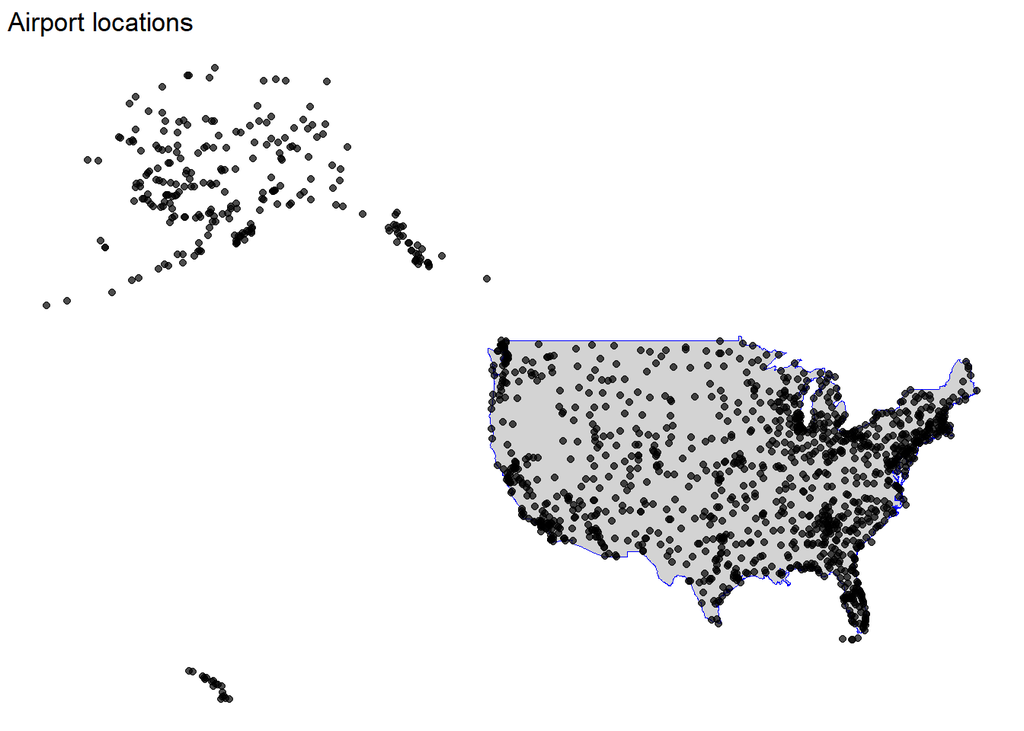

```r
ggplot() +
  geom_map(
    data = US, map = US,
    aes(long, lat, map_id = region),
    color = "blue", fill = "lightgray", size = 0.1)+
    geom_point(
    data = airport_map,
    aes(lon, lat),
    alpha = 0.7)+
  theme_void() +
  theme(legend.position = "none")+
  labs(title = " Airport locations")
```

#### Flights

What is the percentage of late departures in 2013 from the 3 NYC airports?

```r
delay <- flights%>%
  filter(dep_delay > 0)%>%
  nrow()
late_percent <- (delay/nrow(flights))*100
late_percent
```

```
## [1] 38.13573
```

What is the percentage of late arrivals ?

```r
delay_arr <- flights%>%
  filter(arr_delay > 0)%>%
  nrow()
late_arrpercent <- (delay_arr/nrow(flights))*100
late_arrpercent
```

```
## [1] 39.49331
```

What are the percentages or late flights(departure and arrival) per carrier?

```r
carrier_list <- airlines$carrier
```

A function that given a list of carrier names will calculate their personal percentage of late departures and late arrivals and insert the information into a data frame

```r
function1 <- function(carrier_list){
  delay <- c()
  for (i in 1:length(carrier_list)) {
    x <- flights%>%
      filter(carrier == carrier_list[i])%>%
      nrow()
    y <- flights %>%
      filter(carrier == carrier_list[i] & dep_delay > 0)%>%
      nrow()
    z <- (y/x)*100
    delay <- append(delay, z)
  }
  return(delay)
}

function2 <- function(carrier_list){
  delay <- c()
  for (i in 1:length(carrier_list)) {
    x <- flights%>%
      filter(carrier == carrier_list[i])%>%
      nrow()
    y <- flights %>%
      filter(carrier == carrier_list[i] & arr_delay > 0)%>%
      nrow()
    z <- (y/x)*100
    delay <- append(delay, z)
  }
  return(delay)
}
```

```r
departure_delay <- function1(carrier_list)
arrival_delay <- function2(carrier_list)
late_carrier <- data.frame(carrier_list,departure_delay, arrival_delay)
```

```r
late_carrier_pivot <- late_carrier%>%
  pivot_longer(cols = -carrier_list, names_to = "delay_type", values_to = "percetage")
```

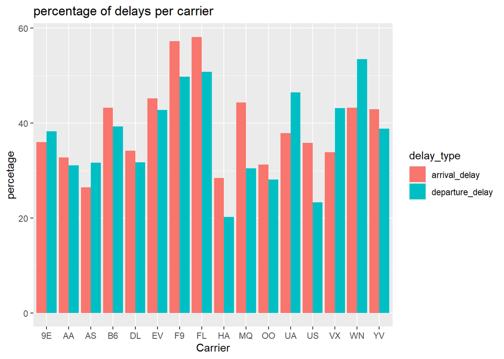

```r
ggplot(late_carrier_pivot, aes(fill=delay_type, y=percetage, x=carrier_list)) +
  geom_bar(position="dodge", stat="identity")+
  labs(title = "percentage of delays per carrier")+
  xlab("Carrier")
```

What are the percentage of total delayed departures per airport

```r
airports_list <- unique(flights$origin)
```

Function

```r
function3 <- function(airports_list){
  delay <- c()
  for(i in airports_list){
    x <- flights%>%
      filter(origin == i & dep_delay > 0)%>%
      nrow()

    y <- flights%>%
      filter(dep_delay > 0)%>%
      nrow()
    z <- (x/y)*100
    delay <- append(delay,z )

  }
  return(data.frame(airports_list,delay))
}
```

```r
origin_delay <- function3(airports_list)
```

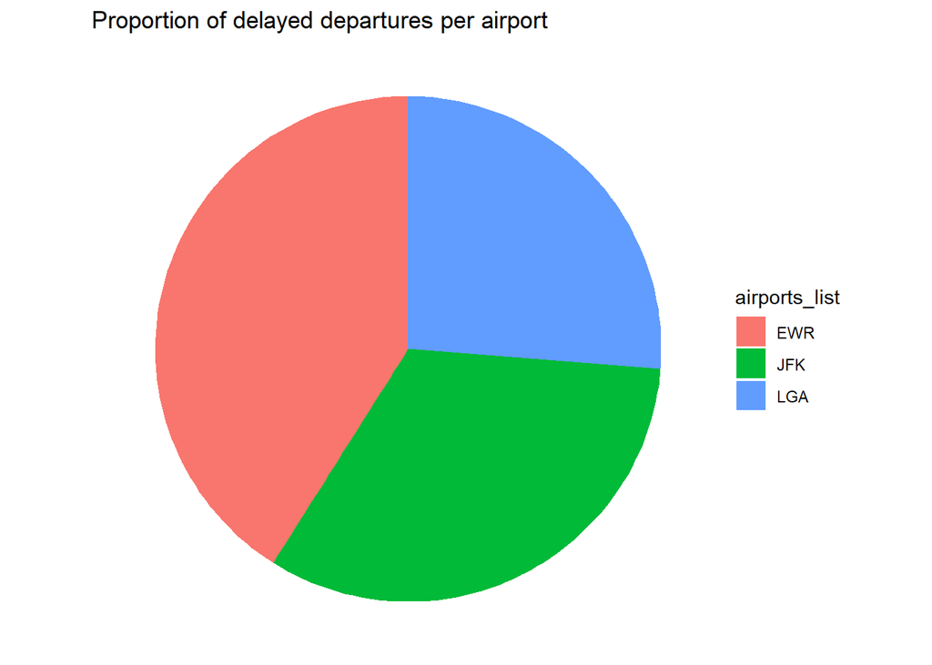

```r
ggplot(origin_delay, aes(x="", y=delay, fill=airports_list)) +
  geom_bar(stat="identity", width=1) +
  coord_polar("y", start=0) +
  theme_void()+
  labs(title = "Proportion of delayed departures per airport")#add title
```

We can see that EWR takes a lion share of late departures

What is the proportion of airtime afforded to each airline/carrier?

```r
function4 <- function(carrier_list){
  airtime_percentage <- c()
  total_airtime <- flights%>%
    dplyr::select(air_time)%>%
    sum(na.rm = TRUE)
  for(i in carrier_list){
    carrier_airtime <- flights%>%
      filter(carrier == i)%>%
      dplyr::select(air_time)%>%
      sum(na.rm = TRUE)
    z <- (carrier_airtime/total_airtime)*100
    airtime_percentage <- append(airtime_percentage,z)
  }
  return (airtime_percentage)
}
```

```r
carrier_air <- function4(carrier_list)
carrier_airtime <- data.frame(carrier_list, carrier_air)
```

And visualization with treemap

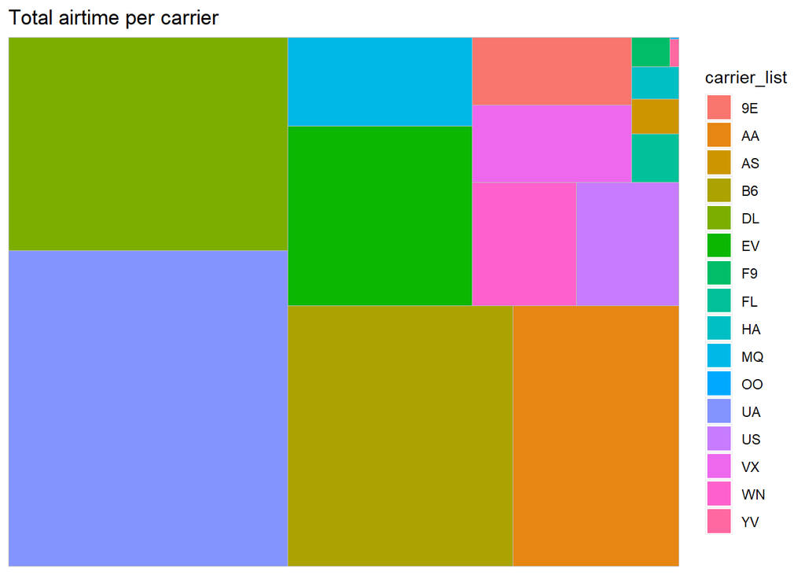

```r
ggplot(carrier_airtime, aes(area = carrier_air, fill = carrier_list)) +
  geom_treemap()+
  labs(title = "Total airtime per carrier")
```

What are the busiest days of the week per month in terms of:

1. number of fligts

First we convert the months and days from numbers to characters

```r
month <- flights$time_hour
flights$month<- months(month)
day <- flights$time_hour
flights$day <- weekdays(day)
```

Then we write a function that will build a dataframe containing the number of flights per weekday and month

```r
month_list <- c("janvier", "février", "mars", "avril", "mai", "juin", "juillet", "août", "septembre", "octobre", "novembre", "décembre")
day_list <- c("lundi", "mardi", "mercredi", "jeudi", "vendredi", "samedi", "dimanche")
```

```r
df <- c()
for(i in month_list){
  x <- c()
  for(j in day_list){
    a <- flights%>%
      filter(month == i, day == j)%>%
      nrow()
    x <- append(x, a)
  }
  df <- data.frame(rbind(df, x))
}
```

Then give appropriate names to the rows and columns

```r
colnames(df)<-day_list
df <- cbind(month_list, df)
```

We pivot the dataframe in order to create a heatmap with ggplot2

```r
df <- df%>%
  pivot_longer(cols = -month_list, names_to = "weekday", values_to = "nb of planes")
```

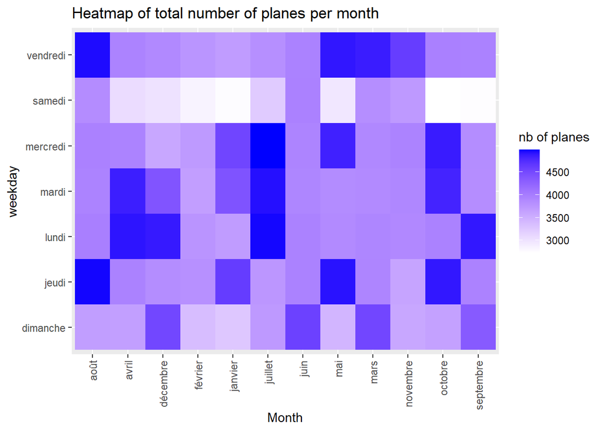

```r
ggplot(df, aes(month_list, weekday, fill= `nb of planes`)) +
  geom_tile() +
  scale_fill_gradient(low="white", high="blue")+
  theme(axis.text.x = element_text(angle = 90, vjust = 0.5, hjust=1)) +
  labs(title = "Heatmap of total number of planes per month")+
  xlab("Month")
```

2. airtime

```r
df2 <- c()
for(i in month_list){
  x <- c()
  for(j in day_list){
    a <- flights%>%
      filter(month == i, day == j)%>%
      na.omit()%>%
      dplyr::select(air_time)%>%
      sum()
    x <- append(x, a)
  }
  df2 <- data.frame(rbind(df2, x))
}
```

```r
colnames(df2)<-day_list
df2 <- cbind(month_list, df2)
```

```r
df2 <- df2%>%
  pivot_longer(cols = -month_list, names_to = "weekday", values_to = "airtime")
```

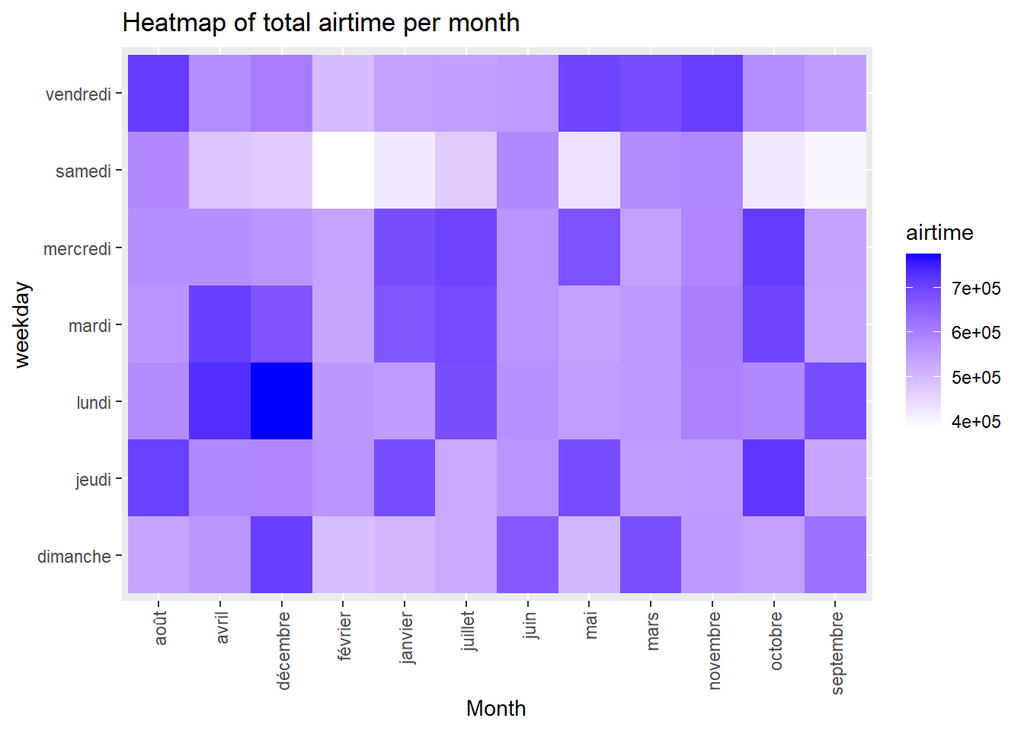

```r
ggplot(df2, aes(month_list, weekday, fill= airtime)) +
  geom_tile() +
  scale_fill_gradient(low="white", high="blue")+
  theme(axis.text.x = element_text(angle = 90, vjust = 0.5, hjust=1)) +
  labs(title = "Heatmap of total airtime per month")+
  xlab("Month")
```